# Biostat 203B Homework 1

Due Jan 26, 2024 @ 11:59PM

Author

Yuhui Wang, UID: 606332401

## Q1. Git/GitHub

**No handwritten homework reports are accepted for this course.** We work with Git and GitHub. Efficient and abundant use of Git, e.g., frequent and well-documented commits, is an important criterion for grading your homework.

1. Apply for the [Student Developer Pack](https://education.github.com/pack) at GitHub using your UCLA email. You’ll get GitHub Pro account for free (unlimited public and private repositories).
2. Create a **private** repository `biostat-203b-2024-winter` and add `Hua-Zhou` and TA team (`Tomoki-Okuno` for Lec 1; `jonathanhori` and `jasenzhang1` for Lec 80) as your collaborators with write permission.
3. Top directories of the repository should be `hw1`, `hw2`, … Maintain two branches `main` and `develop`. The `develop` branch will be your main playground, the place where you develop solution (code) to homework problems and write up report. The `main` branch will be your presentation area. Submit your homework files (Quarto file `qmd`, `html` file converted by Quarto, all code and extra data sets to reproduce results) in the `main` branch.
4. After each homework due date, course reader and instructor will check out your `main` branch for grading. Tag each of your homework submissions with tag names `hw1`, `hw2`, … Tagging time will be used as your submission time. That means if you tag your `hw1` submission after deadline, penalty points will be deducted for late submission.
5. After this course, you can make this repository public and use it to demonstrate your skill sets on job market.

**Answer:** [github](https://github.com/yuhuiwang0801/biostat-203b-2024-winter)

## Q2. Data ethics training

This exercise (and later in this course) uses the [MIMIC-IV data v2.2](https://physionet.org/content/mimiciv/2.2/), a freely accessible critical care database developed by the MIT Lab for Computational Physiology. Follow the instructions at https://mimic.mit.edu/docs/gettingstarted/ to (1) complete the CITI `Data or Specimens Only Research` course and (2) obtain the PhysioNet credential for using the MIMIC-IV data. Display the verification links to your completion report and completion certificate here. **You must complete Q2 before working on the remaining questions.** (Hint: The CITI training takes a few hours and the PhysioNet credentialing takes a couple days; do not leave it to the last minute.)

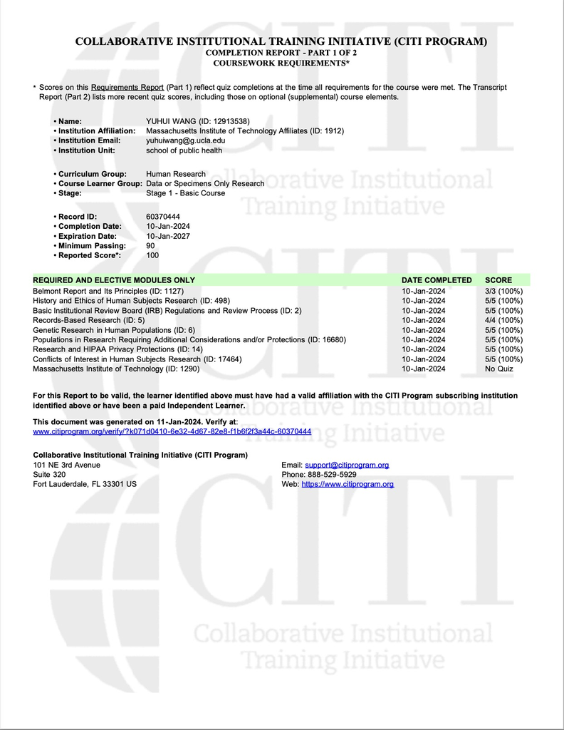

[figure not shown]

## Q3. Linux Shell Commands

1. Make the MIMIC v2.2 data available at location `~/mimic`.

**Answer:** I have downloaded the MIMIC v2.2 data and copy it from my desktop to the folder `~/mimic`, with code:

```bash
cp -r /Users/wang/Desktop/mimic ~/
```

The following code shows the files in the folder.

```bash
ls -l ~/mimic/
```

```
total 1480
-rw-r--r--@  1 wang  staff   13332 Jan 22 15:01 CHANGELOG.txt
-rw-r--r--@  1 wang  staff    2518 Jan 22 15:01 LICENSE.txt
-rw-r--r--@  1 wang  staff    2884 Jan 22 15:01 SHA256SUMS.txt
drwxr-xr-x@ 25 wang  staff     800 Jan 29 01:21 hosp
drwxr-xr-x@ 12 wang  staff     384 Jan 29 01:21 icu
-rwxr--r--   1 wang  staff     137 Jan 22 20:01 middle.sh
-rw-r--r--@  1 wang  staff  725284 Jan 15 12:54 pg42671.txt
```

Refer to the documentation https://physionet.org/content/mimiciv/2.2/ for details of data files. Please, do **not** put these data files into Git; they are big. Do **not** copy them into your directory. Do **not** decompress the gz data files. These create unnecessary big files and are not big-data-friendly practices. Read from the data folder `~/mimic` directly in following exercises.

Use Bash commands to answer following questions.

2. Display the contents in the folders `hosp` and `icu` using Bash command `ls -l`. Why are these data files distributed as `.csv.gz` files instead of `.csv` (comma separated values) files? Read the page https://mimic.mit.edu/docs/iv/ to understand what’s in each folder.

**Answer:**

```bash
# display the contents in the folders hosp and icu
ls -l ~/mimic/hosp
ls -l ~/mimic/icu
```

```
total 8859752
-rw-r--r--@ 1 wang  staff    15516088 Jan 22 15:01 admissions.csv.gz
-rw-r--r--@ 1 wang  staff      427468 Jan 22 15:01 d_hcpcs.csv.gz
-rw-r--r--@ 1 wang  staff      859438 Jan 22 15:01 d_icd_diagnoses.csv.gz
-rw-r--r--@ 1 wang  staff      578517 Jan 22 15:01 d_icd_procedures.csv.gz
-rw-r--r--@ 1 wang  staff       12900 Jan 22 15:01 d_labitems.csv.gz
-rw-r--r--@ 1 wang  staff    25070720 Jan 22 15:01 diagnoses_icd.csv.gz
-rw-r--r--@ 1 wang  staff     7426955 Jan 22 15:01 drgcodes.csv.gz
-rw-r--r--@ 1 wang  staff   508524623 Jan 22 15:01 emar.csv.gz
-rw-r--r--@ 1 wang  staff   471096030 Jan 22 15:01 emar_detail.csv.gz
-rw-r--r--@ 1 wang  staff     1767138 Jan 22 15:01 hcpcsevents.csv.gz
-rw-r--r--@ 1 wang  staff  1939088924 Jan 22 15:01 labevents.csv.gz
-rw-r--r--@ 1 wang  staff    96698496 Jan 22 15:01 microbiologyevents.csv.gz
-rw-r--r--@ 1 wang  staff    36124944 Jan 22 15:01 omr.csv.gz
-rw-r--r--@ 1 wang  staff     2312631 Jan 22 15:01 patients.csv.gz
-rw-r--r--@ 1 wang  staff   398753125 Jan 22 15:01 pharmacy.csv.gz
-rw-r--r--@ 1 wang  staff   498505135 Jan 22 15:01 poe.csv.gz
-rw-r--r--@ 1 wang  staff    25477219 Jan 22 15:01 poe_detail.csv.gz
-rw-r--r--@ 1 wang  staff   458817415 Jan 22 15:01 prescriptions.csv.gz
-rw-r--r--@ 1 wang  staff     6027067 Jan 22 15:01 procedures_icd.csv.gz
-rw-r--r--@ 1 wang  staff      122507 Jan 22 15:01 provider.csv.gz
-rw-r--r--@ 1 wang  staff     6781247 Jan 22 15:01 services.csv.gz
-rw-r--r--@ 1 wang  staff    36158338 Jan 22 15:01 transfers.csv.gz
total 6155968
-rw-r--r--@ 1 wang  staff       35893 Jan 22 15:01 caregiver.csv.gz
-rw-r--r--@ 1 wang  staff  2467761053 Jan 22 15:01 chartevents.csv.gz
-rw-r--r--@ 1 wang  staff       57476 Jan 22 15:01 d_items.csv.gz
-rw-r--r--@ 1 wang  staff    45721062 Jan 22 15:01 datetimeevents.csv.gz
-rw-r--r--@ 1 wang  staff     2614571 Jan 22 15:01 icustays.csv.gz
-rw-r--r--@ 1 wang  staff   251962313 Jan 22 15:01 ingredientevents.csv.gz
-rw-r--r--@ 1 wang  staff   324218488 Jan 22 15:01 inputevents.csv.gz
-rw-r--r--@ 1 wang  staff    38747895 Jan 22 15:01 outputevents.csv.gz
-rw-r--r--@ 1 wang  staff    20717852 Jan 22 15:01 procedureevents.csv.gz
```

That is because the data files are too large to be stored in `.csv` files. The `.csv.gz` files are compressed files, which are much smaller than the original files.

3. Briefly describe what Bash commands `zcat`, `zless`, `zmore`, and `zgrep` do.

**Answer:**

```bash
printf "zcat\n"
man zcat | head -30
```

[output not shown]

```bash
printf "zless\n"
man zless | head -30
```

[output not shown]

```bash
printf "zmore\n"
man zmore | head -30
```

[output not shown]

```bash
printf "zgrep\n"
man zgrep | head -30
```

[output not shown]

`zcat` is used to display the contents of a compressed file. `zless` is used to display the contents of a compressed file one screenful at a time. `zmore` is used to display the contents of a compressed file one screenful at a time. `zgrep` is used to search through compressed files for a regular expression.

4. (Looping in Bash) What’s the output of the following bash script?

```bash
for datafile in ~/mimic/hosp/{a,l,pa}*.gz
do
  ls -l $datafile
done
```

```
-rw-r--r--@ 1 wang  staff  15516088 Jan 22 15:01 /Users/wang/mimic/hosp/admissions.csv.gz
-rw-r--r--@ 1 wang  staff  1939088924 Jan 22 15:01 /Users/wang/mimic/hosp/labevents.csv.gz
-rw-r--r--@ 1 wang  staff  2312631 Jan 22 15:01 /Users/wang/mimic/hosp/patients.csv.gz
```

Display the number of lines in each data file using a similar loop. (Hint: combine linux commands `zcat <` and `wc -l`.)

**Answer:**

```bash
for datafile in ~/mimic/hosp/{a,l,pa}*.gz
do
  printf "$datafile\n"
  zcat < $datafile | wc -l
done
```

```
/Users/wang/mimic/hosp/admissions.csv.gz
  431232
/Users/wang/mimic/hosp/labevents.csv.gz
 118171368
/Users/wang/mimic/hosp/patients.csv.gz
  299713
```

5. Display the first few lines of `admissions.csv.gz`. How many rows are in this data file? How many unique patients (identified by `subject_id`) are in this data file? Do they match the number of patients listed in the `patients.csv.gz` file? (Hint: combine Linux commands `zcat <`, `head`/`tail`, `awk`, `sort`, `uniq`, `wc`, and so on.)

**Answer:**

```bash
printf "The first 5 lines of admissions.csv.gz are:\n"
zcat < ~/mimic/hosp/admissions.csv.gz | head -5
```

```
The first 5 lines of admissions.csv.gz are:
subject_id,hadm_id,admittime,dischtime,deathtime,admission_type,admit_provider_id,admission_location,discharge_location,insurance,language,marital_status,race,edregtime,edouttime,hospital_expire_flag
10000032,22595853,2180-05-06 22:23:00,2180-05-07 17:15:00,,URGENT,P874LG,TRANSFER FROM HOSPITAL,HOME,Other,ENGLISH,WIDOWED,WHITE,2180-05-06 19:17:00,2180-05-06 23:30:00,0
10000032,22841357,2180-06-26 18:27:00,2180-06-27 18:49:00,,EW EMER.,P09Q6Y,EMERGENCY ROOM,HOME,Medicaid,ENGLISH,WIDOWED,WHITE,2180-06-26 15:54:00,2180-06-26 21:31:00,0
10000032,25742920,2180-08-05 23:44:00,2180-08-07 17:50:00,,EW EMER.,P60CC5,EMERGENCY ROOM,HOSPICE,Medicaid,ENGLISH,WIDOWED,WHITE,2180-08-05 20:58:00,2180-08-06 01:44:00,0
10000032,29079034,2180-07-23 12:35:00,2180-07-25 17:55:00,,EW EMER.,P30KEH,EMERGENCY ROOM,HOME,Medicaid,ENGLISH,WIDOWED,WHITE,2180-07-23 05:54:00,2180-07-23 14:00:00,0
```

```bash
printf "The number of rows in this data file is:\n"
zcat < ~/mimic/hosp/admissions.csv.gz | wc -l
```

```
The number of rows in this data file is:
  431232
```

```bash
printf "The number of unique patients is:\n"
zcat < ~/mimic/hosp/admissions.csv.gz | awk -F, '{print $1}' | sort | uniq | wc -l
```

```
The number of unique patients is:
  180734
```

```bash
printf "The number of patients listed in the patients.csv.gz file is:\n"
zcat < ~/mimic/hosp/patients.csv.gz | wc -l
```

```
The number of patients listed in the patients.csv.gz file is:
  299713
```

Therefore, the number of unique patients in `admissions.csv.gz` does not match the number of patients listed in the `patients.csv.gz` file.

6. What are the possible values taken by each of the variable `admission_type`, `admission_location`, `insurance`, and `ethnicity`? Also report the count for each unique value of these variables. (Hint: combine Linux commands `zcat`, `head`/`tail`, `awk`, `uniq -c`, `wc`, and so on; skip the header line.)

**Answer:**

```bash
printf "The possible values taken by admission_type are:\n"
zcat < ~/mimic/hosp/admissions.csv.gz | awk -F, 'NR > 1 {print $6}' | sort | uniq -c
```

```
The possible values taken by admission_type are:
6626 AMBULATORY OBSERVATION
19554 DIRECT EMER.
18707 DIRECT OBSERVATION
10565 ELECTIVE
94776 EU OBSERVATION
149413 EW EMER.
52668 OBSERVATION ADMIT
34231 SURGICAL SAME DAY ADMISSION
44691 URGENT
```

```bash
printf "The possible values taken by admission_location are:\n"
zcat < ~/mimic/hosp/admissions.csv.gz | awk -F, 'NR > 1 {print $8}' | sort | uniq -c
```

```
The possible values taken by admission_location are:
 185 AMBULATORY SURGERY TRANSFER
10008 CLINIC REFERRAL
232595 EMERGENCY ROOM
 359 INFORMATION NOT AVAILABLE
4205 INTERNAL TRANSFER TO OR FROM PSYCH
5479 PACU
114963 PHYSICIAN REFERRAL
7804 PROCEDURE SITE
35974 TRANSFER FROM HOSPITAL
3843 TRANSFER FROM SKILLED NURSING FACILITY
15816 WALK-IN/SELF REFERRAL
```

```bash
printf "The possible values taken by insurance are:\n"
zcat < ~/mimic/hosp/admissions.csv.gz | awk -F, 'NR > 1 {print $10}' | sort | uniq -c
```

```
The possible values taken by insurance are:
41330 Medicaid
160560 Medicare
229341 Other
```

```bash
printf "The possible values taken by ethnicity are:\n"
zcat < ~/mimic/hosp/admissions.csv.gz | awk -F, 'NR > 1 {print $13}' | sort | uniq -c
```

```
The possible values taken by ethnicity are:
 919 AMERICAN INDIAN/ALASKA NATIVE
6156 ASIAN
1198 ASIAN - ASIAN INDIAN
5587 ASIAN - CHINESE
 506 ASIAN - KOREAN
1446 ASIAN - SOUTH EAST ASIAN
2530 BLACK/AFRICAN
59959 BLACK/AFRICAN AMERICAN
4765 BLACK/CAPE VERDEAN
2704 BLACK/CARIBBEAN ISLAND
7754 HISPANIC OR LATINO
 437 HISPANIC/LATINO - CENTRAL AMERICAN
 639 HISPANIC/LATINO - COLUMBIAN
 500 HISPANIC/LATINO - CUBAN
```

[output cut: 19 more lines]

7. *To compress, or not to compress. That’s the question.* Let’s focus on the big data file `labevents.csv.gz`. Compare compressed gz file size to the uncompressed file size. Compare the run times of `zcat < ~/mimic/labevents.csv.gz | wc -l` versus `wc -l labevents.csv`. Discuss the trade off between storage and speed for big data files. (Hint: `gzip -dk < FILENAME.gz > ./FILENAME`. Remember to delete the large `labevents.csv` file after the exercise.)

**Answer:**

```bash
printf "The compressed gz file size is:\n"
ls -lh ~/mimic/hosp/labevents.csv.gz
```

```
The compressed gz file size is:
-rw-r--r--@ 1 wang  staff   1.8G Jan 22 15:01 /Users/wang/mimic/hosp/labevents.csv.gz
```

```bash
gzip -dk < ~/mimic/hosp/labevents.csv.gz > ./labevents.csv
printf "The uncompressed file size is:\n"
ls -lh labevents.csv
```

```
The uncompressed file size is:
-rw-r--r--  1 wang  staff    13G Feb  8 18:58 labevents.csv
```

```bash
printf "The run time comparison for compressed and uncompressed files are:\n"
time zcat < ~/mimic/hosp/labevents.csv.gz | wc -l
time wc -l labevents.csv
```

```
The run time comparison for compressed and uncompressed files are:
 118171368

real    0m18.303s
user    0m24.291s
sys 0m4.051s
 118171368 labevents.csv

real    0m17.278s
user    0m13.824s
sys 0m1.749s
```

In general, it is a trade off between storage and speed. However, it is worth to use compressed files since the run time is not much longer than the uncompressed file, while the compressed file size is much smaller than the uncompressed file size.

## Q4. Who’s popular in Price and Prejudice

1. You and your friend just have finished reading *Pride and Prejudice* by Jane Austen. Among the four main characters in the book, Elizabeth, Jane, Lydia, and Darcy, your friend thinks that Darcy was the most mentioned. You, however, are certain it was Elizabeth. Obtain the full text of the novel from http://www.gutenberg.org/cache/epub/42671/pg42671.txt and save to your local folder.

```bash
wget -nc http://www.gutenberg.org/cache/epub/42671/pg42671.txt
```

Explain what `wget -nc` does. Do **not** put this text file `pg42671.txt` in Git. Complete the following loop to tabulate the number of times each of the four characters is mentioned using Linux commands.

**Answer:** `wget -nc` downloads the file from the given URL if it does not exist in the current directory, and does nothing if it already exists.

```bash
wget -nc http://www.gutenberg.org/cache/epub/42671/pg42671.txt
for char in Elizabeth Jane Lydia Darcy
do
  echo $char:
  # some bash commands here
  grep -o -i $char pg42671.txt | wc -l

done
```

```
bash: wget: command not found
Elizabeth:
     634
Jane:
     293
Lydia:
     171
Darcy:
     418
```

2. What’s the difference between the following two commands?

```bash
echo 'hello, world' > test1.txt
```

and

```bash
echo 'hello, world' >> test2.txt
```

**Answer:** The first command will overwrite the file `test1.txt` if it already exists, while the second command will append the text to the end of the file `test2.txt` if it already exists.

3. Using your favorite text editor (e.g., `vi`), type the following and save the file as `middle.sh`:

```bash
#!/bin/sh
# Select lines from the middle of a file.
# Usage: bash middle.sh filename end_line num_lines
head -n "$2" "$1" | tail -n "$3"
```

Using `chmod` to make the file executable by the owner, and run

```bash
./middle.sh pg42671.txt 20 5
```

Explain the output. Explain the meaning of `"$1"`, `"$2"`, and `"$3"` in this shell script. Why do we need the first line of the shell script?

**Answer:**

```bash
chmod +x middle.sh
./middle.sh pg42671.txt 20 5
```

```
Editor: R. W. Chapman

Release date: May 9, 2013 [eBook #42671]

Language: English
```

The output is the 5 lines starting from the 16th line to the 20th line of the file `pg42671.txt`. `"$1"`, `"$2"`, and `"$3"` are the first, second, and third arguments of the shell script, and it will be clarified when executing. We need the first line of the shell script to tell the system that this is a shell script.

## Q5. More fun with Linux

Try following commands in Bash and interpret the results: `cal`, `cal 2024`, `cal 9 1752` (anything unusual?), `date`, `hostname`, `arch`, `uname -a`, `uptime`, `who am i`, `who`, `w`, `id`, `last | head`, `echo {con,pre}{sent,fer}{s,ed}`, `time sleep 5`, `history | tail`.

**Answer:**

```bash
printf "cal:\n"
cal
printf "cal 2024:\n"
cal 2024
printf "cal 9 1752:\n"
cal 9 1752
```

```
cal:
   February 2024
Su Mo Tu We Th Fr Sa
             1  2  3
 4  5  6  7 _ _8  9 10
11 12 13 14 15 16 17
18 19 20 21 22 23 24
25 26 27 28 29

cal 2024:
                            2024
      January               February               March
Su Mo Tu We Th Fr Sa  Su Mo Tu We Th Fr Sa  Su Mo Tu We Th Fr Sa
    1  2  3  4  5  6               1  2  3                  1  2
 7  8  9 10 11 12 13   4  5  6  7 _ _8  9 10   3  4  5  6  7  8  9
14 15 16 17 18 19 20  11 12 13 14 15 16 17  10 11 12 13 14 15 16
21 22 23 24 25 26 27  18 19 20 21 22 23 24  17 18 19 20 21 22 23
28 29 30 31           25 26 27 28 29        24 25 26 27 28 29 30
                                            31

       April                  May                   June
Su Mo Tu We Th Fr Sa  Su Mo Tu We Th Fr Sa  Su Mo Tu We Th Fr Sa
    1  2  3  4  5  6            1  2  3  4                     1
 7  8  9 10 11 12 13   5  6  7  8  9 10 11   2  3  4  5  6  7  8
14 15 16 17 18 19 20  12 13 14 15 16 17 18   9 10 11 12 13 14 15
21 22 23 24 25 26 27  19 20 21 22 23 24 25  16 17 18 19 20 21 22
28 29 30              26 27 28 29 30 31     23 24 25 26 27 28 29
                                            30

        July                 August              September
Su Mo Tu We Th Fr Sa  Su Mo Tu We Th Fr Sa  Su Mo Tu We Th Fr Sa
    1  2  3  4  5  6               1  2  3   1  2  3  4  5  6  7
 7  8  9 10 11 12 13   4  5  6  7  8  9 10   8  9 10 11 12 13 14
14 15 16 17 18 19 20  11 12 13 14 15 16 17  15 16 17 18 19 20 21
21 22 23 24 25 26 27  18 19 20 21 22 23 24  22 23 24 25 26 27 28
28 29 30 31           25 26 27 28 29 30 31  29 30


      October               November              December
Su Mo Tu We Th Fr Sa  Su Mo Tu We Th Fr Sa  Su Mo Tu We Th Fr Sa
       1  2  3  4  5                  1  2   1  2  3  4  5  6  7
 6  7  8  9 10 11 12   3  4  5  6  7  8  9   8  9 10 11 12 13 14
13 14 15 16 17 18 19  10 11 12 13 14 15 16  15 16 17 18 19 20 21
20 21 22 23 24 25 26  17 18 19 20 21 22 23  22 23 24 25 26 27 28
27 28 29 30 31        24 25 26 27 28 29 30  29 30 31

cal 9 1752:
   September 1752
Su Mo Tu We Th Fr Sa
       1  2 14 15 16
17 18 19 20 21 22 23
24 25 26 27 28 29 30
```

```bash
printf "date:\n"
date
```

```
date:
Thu Feb  8 18:58:38 PST 2024
```

```bash
printf "hostname:\n"
hostname
```

```
hostname:
Stefans-Air.lan
```

```bash
printf "arch:\n"
arch
```

```
arch:
arm64
```

```bash
printf "uname -a:\n"
uname -a
```

```
uname -a:
Darwin Stefans-Air.lan 23.2.0 Darwin Kernel Version 23.2.0: Wed Nov 15 21:59:33 PST 2023; root:xnu-10002.61.3~2/RELEASE_ARM64_T8112 arm64
```

```bash
printf "uptime:\n"
uptime
```

```
uptime:
18:58  up 24 days,  2:19, 1 user, load averages: 6.93 6.66 6.41
```

```bash
printf "who am i:\n"
who am i
```

```
who am i:
wang                          Feb  8 18:58
```

```bash
printf "who:\n"
who
```

```
who:
wang             console      Jan 15 16:41
```

```bash
printf "w:\n"
w
```

```
w:
18:58  up 24 days,  2:19, 1 user, load averages: 6.93 6.66 6.41
USER     TTY      FROM              LOGIN@  IDLE WHAT
wang     console  -                15Jan24 24days -
```

```bash
printf "id:\n"
id
```

```
id:
uid=501(wang) gid=20(staff) groups=20(staff),12(everyone),61(localaccounts),79(_appserverusr),80(admin),81(_appserveradm),98(_lpadmin),33(_appstore),100(_lpoperator),204(_developer),250(_analyticsusers),395(com.apple.access_ftp),398(com.apple.access_screensharing),399(com.apple.access_ssh),400(com.a…
```

```bash
printf "last | head:\n"
last | head
```

```
last | head:
wang       ttys001                         Sat Jan 27 15:51 - 15:51  (00:00)
wang       ttys000                         Wed Jan 24 09:28 - 09:28  (00:00)
wang       ttys000                         Tue Jan 23 15:02 - 15:02  (00:00)
wang       ttys002                         Tue Jan 23 15:00 - 15:00  (00:00)
wang       ttys001                         Tue Jan 23 14:58 - 14:58  (00:00)
wang       ttys001                         Tue Jan 23 14:57 - 14:57  (00:00)
wang       ttys000                         Tue Jan 23 13:57 - 13:57  (00:00)
wang       ttys000                         Tue Jan 23 09:35 - 09:35  (00:00)
wang       ttys000                         Fri Jan 19 16:47 - 16:47  (00:00)
wang       ttys000                         Mon Jan 15 20:29 - 20:29  (00:00)
```

```bash
printf "echo {con,pre}{sent,fer}{s,ed}:\n"
echo {con,pre}{sent,fer}{s,ed}
```

```
echo {con,pre}{sent,fer}{s,ed}:
consents consented confers confered presents presented prefers prefered
```

```bash
printf "time sleep 5:\n"
time sleep 5
```

```
time sleep 5:

real    0m5.018s
user    0m0.000s
sys 0m0.001s
```

```bash
printf "history | tail:\n"
history | tail
```

```
history | tail:
```

cal: Displays the calendar for the current month.

cal 2024: Shows the calendar for the entire year 2024.

cal 9 1752: Displays the calendar for September 1752. The calendar for September 1752 is different from other months because the Gregorian calendar was adopted in September 1752, and 11 days were skipped to make up for the difference between the Julian calendar and the Gregorian calendar.

date: Displays the current date and time.

hostname: Displays the name of the host.

arch: Displays the machine architecture.

uname -a: Displays the system information.

uptime: Displays the current time, how long the system has been running, how many users are currently logged on, and the system load averages for the past 1, 5, and 15 minutes.

who am i: Displays the current user.

who: Displays the users who are currently logged on.

w: Displays the users who are currently logged on and what they are doing.

id: Displays the current user’s UID, GID, and groups.

last | head: Displays the last 10 logins.

time sleep 5: Displays the time it takes to execute the command “sleep 5”.

history | tail: Displays the last 10 commands in the history.

## Q6. Book

1. Git clone the repository https://github.com/christophergandrud/Rep-Res-Book for the book *Reproducible Research with R and RStudio* to your local machine.
2. Open the project by clicking `rep-res-3rd-edition.Rproj` and compile the book by clicking `Build Book` in the `Build` panel of RStudio. (Hint: I was able to build `git_book` and `epub_book` but not `pdf_book`.)

The point of this exercise is (1) to get the book for free and (2) to see an example how a complicated project such as a book can be organized in a reproducible way.

For grading purpose, include a screenshot of Section 4.1.5 of the book here.

**Answer:**

[figure not shown]